# Bellabeat Case Study Analysis

Karo

2025-07-24

# 🧠 Project Overview

## 🎯 Purpose

To analyze user behavior in the Bellabeat app using Fitbit data, with the goal of uncovering patterns in activity, sleep, and weight tracking. These insights will inform Bellabeat’s marketing strategy by identifying which features drive engagement, how users differ in their habits, and what opportunities exist to improve retention and promote healthier behavior through targeted campaigns.

# 🧭 Objectives

- Clean and prepare raw Fitbit datasets
- Explore relationships between steps, sleep, and weight tracking
- Identify user engagement levels and segment users accordingly
- Compare behavioral patterns across segments
- Translate findings into product-focused recommendations

# 🏢 Business Context

Bellabeat is a wellness tech company offering smart devices and apps to help women monitor their health. Understanding how users engage with the app is essential for improving feature adoption, long-term retention, and personalized habit support.

# 📋 Notes

- This analysis is structured across multiple stages, each documented with code, visuals, and insights
- All visualizations are generated using ggplot2 and follow a consistent color scheme for clarity
- Conclusions are written with both technical and stakeholder audiences in mind

# Data Cleaning Phase

### Purpose

Prepare the raw Fitbit datasets for analysis by cleaning missing values, formatting dates, and standardizing column names across all sources.

### Note

This step ensures that our analysis is built on reliable data. We remove duplicates, handle inconsistencies, and confirm data completeness — so every chart, metric, and insight that follows is trustworthy and reproducible.

```r
# Load required packages
library(readr)
library(dplyr)
library(lubridate)
library(janitor)
library(knitr)
library(tibble)

# Import raw datasets
daily_activity <- read_csv("daily_activity_merged.csv")
sleep_per_minute <- read_csv("minuteSleep_merged.csv")
weight_tracking <- read_csv("weightLogInfo_merged.csv")

# Clean daily activity data
daily_activity_clean <- daily_activity %>%
  distinct() %>%
  mutate(ActivityDate = mdy(ActivityDate)) %>%
  clean_names()

# Clean sleep data
sleep_per_minute_clean <- sleep_per_minute %>%
  distinct() %>%
  clean_names()

# Clean weight tracking data
weight_tracking_clean <- weight_tracking %>%
  distinct() %>%
  clean_names()

# Check for missing values in each dataset

## Daily Activity
kable(enframe(colSums(is.na(daily_activity_clean)),
              name = "Column", value = "Missing Values"))
```

| Column | Missing Values |
| --- | --- |
| id | 0 |
| activity_date | 0 |
| total_steps | 0 |
| total_distance | 0 |
| tracker_distance | 0 |
| logged_activities_distance | 0 |
| very_active_distance | 0 |
| moderately_active_distance | 0 |
| light_active_distance | 0 |
| sedentary_active_distance | 0 |
| very_active_minutes | 0 |
| fairly_active_minutes | 0 |
| lightly_active_minutes | 0 |
| sedentary_minutes | 0 |
| calories | 0 |

```r
## Sleep Per Minute
kable(enframe(colSums(is.na(sleep_per_minute_clean)),
              name = "Column", value = "Missing Values"))
```

| Column | Missing Values |
| --- | --- |
| id | 0 |
| date | 0 |
| value | 0 |
| log_id | 0 |

```r
## Weight Tracking
kable(enframe(colSums(is.na(weight_tracking_clean)),
              name = "Column", value = "Missing Values"))
```

| Column | Missing Values |
| --- | --- |
| id | 0 |
| date | 0 |
| weight_kg | 0 |
| weight_pounds | 0 |
| fat | 31 |
| bmi | 0 |
| is_manual_report | 0 |
| log_id | 0 |

```r
# Save cleaned datasets
write_csv(daily_activity_clean, "cleaned_daily_activity.csv")
write_csv(sleep_per_minute_clean, "cleaned_sleep_per_minute.csv")
write_csv(weight_tracking_clean, "cleaned_weight_tracking.csv")
```

### Conclusion

This foundation allows Bellabeat’s user behavior analysis to proceed confidently. Clean data ensures our findings reflect real usage patterns and can be trusted for strategic decisions.

# 📊 Analysis Phase 1: Steps and Calories

### Purpose

Analyze the relationship between users’ daily steps and calories burned to understand how physical activity impacts energy expenditure.

```r
# Load required packages
library(readr)
library(dplyr)
library(lubridate)
library(ggplot2)

# Import cleaned dataset
daily_activity_clean <- read_csv("cleaned_daily_activity.csv")

# Calculate the Pearson correlation coefficient
correlation <- cor(daily_activity_clean$total_steps, daily_activity_clean$calories, use = "complete.obs")

# Print the result
print(paste("Correlation between Total Steps and Calories Burned:", round(correlation, 3)))
```

```
## [1] "Correlation between Total Steps and Calories Burned: 0.581"
```

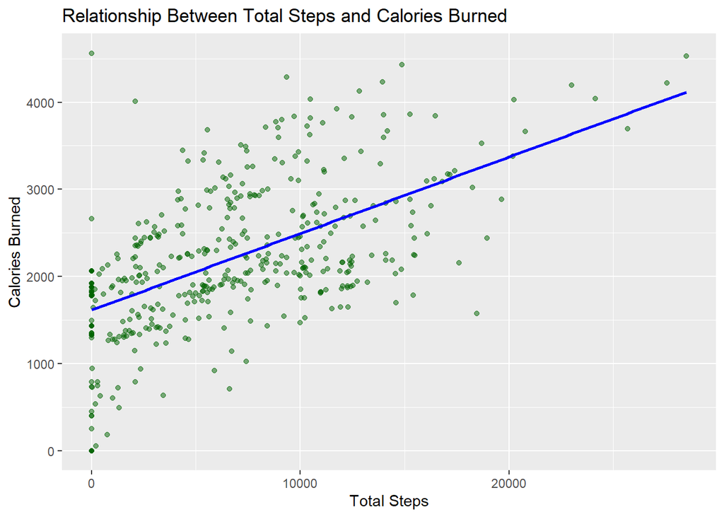

```r
# Visualize the relationship
ggplot(daily_activity_clean, aes(x = total_steps, y = calories)) +
  geom_point(alpha = 0.5, color = "darkgreen") +
  geom_smooth(method = "lm", se = FALSE, color = "blue") +
  labs(
    title = "Relationship Between Total Steps and Calories Burned",
    x = "Total Steps",
    y = "Calories Burned"
  )
```

### Interpretation

A correlation of around 0.58 suggests a moderate positive relationship: - As users take more steps, they tend to burn more calories. - Other factors like activity intensity and duration also play a role.

#### So what?:

“Bellabeat can bundle step challenges with nutrition insights in the app (e.g., ‘Hit 10K steps to unlock hydration tips’). This incentivizes activity while promoting the Spring water bottle as a hydration companion.”

# 📊 Analysis Phase 2: Steps and Sleep Duration

### Purpose

Analyze how daily steps relate to total sleep duration to uncover patterns between activity and rest.

```r
# Load required packages
library(dplyr)
library(lubridate)
library(ggplot2)

# Prepare sleep data
sleep_summary <- sleep_per_minute_clean %>%
  mutate(sleep_day = as_date(mdy_hms(date))) %>%
  group_by(id, sleep_day) %>%
  summarise(total_minutes_asleep = sum(value == 1, na.rm = TRUE), .groups = "drop")

# Prepare activity data
activity_summary <- daily_activity_clean %>%
  mutate(activity_date = as_date(activity_date))

# Merge sleep and activity data
sleep_activity <- inner_join(
  sleep_summary,
  activity_summary,
  by = c("id" = "id", "sleep_day" = "activity_date")
)

# Calculate correlation
correlation_sleep_steps <- cor(sleep_activity$total_steps, sleep_activity$total_minutes_asleep, use = "complete.obs")
print(paste("Correlation between Total Steps and Minutes Asleep:", round(correlation_sleep_steps, 3)))
```

```
## [1] "Correlation between Total Steps and Minutes Asleep: -0.18"
```

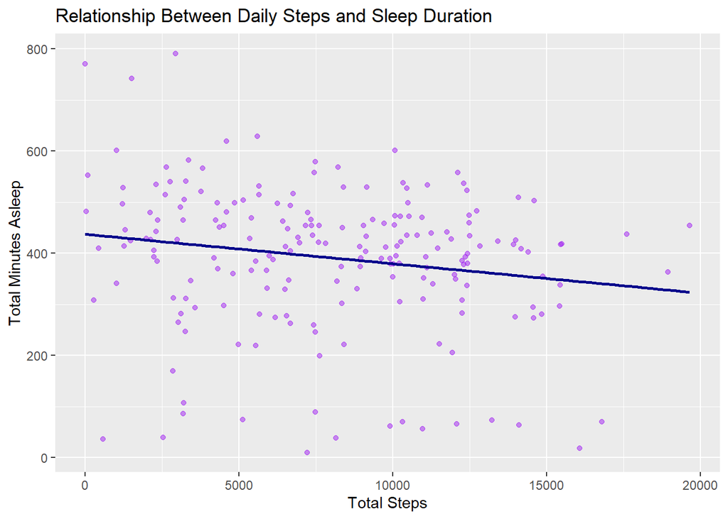

```r
# Visualize the relationship
ggplot(sleep_activity, aes(x = total_steps, y = total_minutes_asleep)) +
  geom_point(alpha = 0.5, color = "purple") +
  geom_smooth(method = "lm", se = FALSE, color = "darkblue") +
  labs(
    title = "Relationship Between Daily Steps and Sleep Duration",
    x = "Total Steps",
    y = "Total Minutes Asleep"
  )
```

### Interpretation

#### So what?:

Leverage the Time watch’s sleep mode to send recovery reminders after high-step days (e.g., ‘You walked 12K steps today! Wind down by 10 PM’). Position it as a tool for balanced wellness, not just activity tracking.

# 📊 Analysis Phase 3: Weight Trends Analysis

### Purpose

To understand how consistently users log their weight and identify behavioral patterns in weight tracking. This helps highlight drop-off points and opportunities to improve user motivation and retention around health goals.

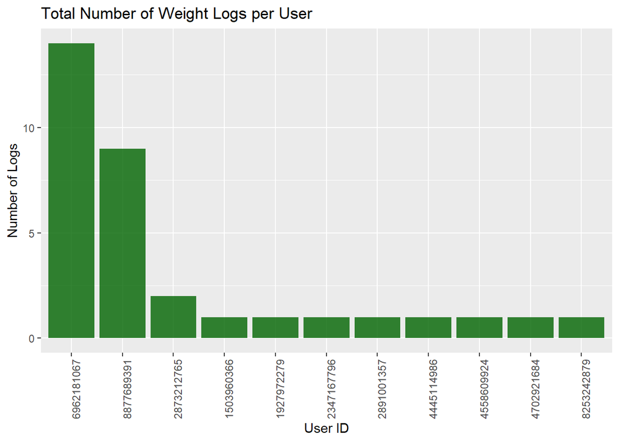

```r
# Load required packages
library(dplyr)
library(lubridate)
library(ggplot2)

# Prepare weight data
weight_tracking_clean <- weight_tracking_clean %>%
  mutate(weight_date = as_date(mdy_hms(date))) %>%
  filter(!is.na(weight_date))

# Total logs per user
logs_per_user <- weight_tracking_clean %>%
  group_by(id) %>%
  summarise(total_logs = n())

ggplot(logs_per_user, aes(x = reorder(id, -total_logs), y = total_logs)) +
  geom_col(fill = "darkgreen", alpha = 0.8) +
  labs(
    title = "Total Number of Weight Logs per User",
    x = "User ID",
    y = "Number of Logs"
  ) +
  theme(axis.text.x = element_text(angle = 90, hjust = 1))
```

### interpretation

These findings underscore the need to evaluate and possibly redesign the feature to better align with user goals and motivations. Considerations include introducing prompts, improving feedback mechanisms, and enhancing the perceived benefit of regular tracking.

#### So what?:

“Gamify weight tracking via the Leaf tracker’s app notifications (e.g., ‘Log weight 3x this week to earn a mindfulness meditation guide’). Tie consistency to membership rewards, boosting engagement.”

#—

# 📊 Analysis Phase 4: User Engagement Analysis

### Purpose

To examine how often users log their **activity**, **sleep**, and **weight** data to uncover engagement trends and spot opportunities to strengthen habits with Bellabeat’s app features.

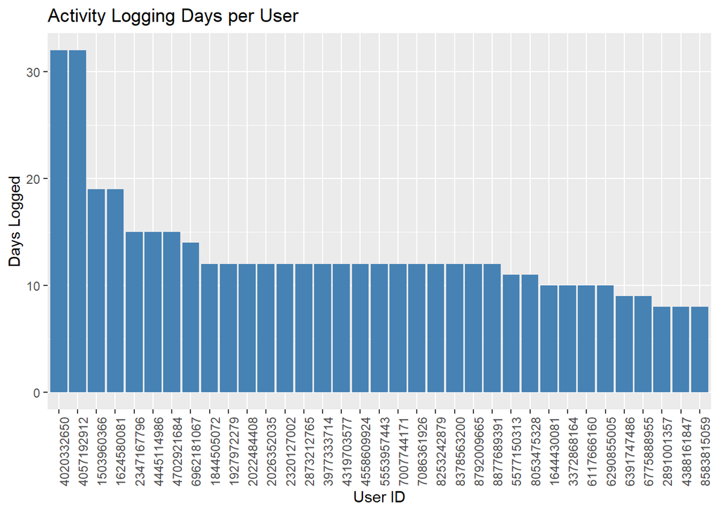

```r
# 📦 Load required packages
library(dplyr)
library(lubridate)
library(ggplot2)

# Ensure correct date format
daily_activity_clean <- daily_activity_clean %>% mutate(activity_date = as_date(activity_date))

# Activity logging days
activity_engagement <- daily_activity_clean %>%
  group_by(id) %>%
  summarise(activity_days_logged = n_distinct(activity_date), .groups = "drop")

# 📊 Activity logging plot
print(
  ggplot(activity_engagement, aes(x = reorder(id, -activity_days_logged), y = activity_days_logged)) +
    geom_bar(stat = "identity", fill = "steelblue") +
    labs(title = "Activity Logging Days per User", x = "User ID", y = "Days Logged") +
    theme(axis.text.x = element_text(angle = 90, hjust = 1))
)
```

### interpretation:

The activity logging data shows that user engagement falls into three clear patterns:

Occasionally Active (60%) – Track 1-3 times per week

#### So what?:

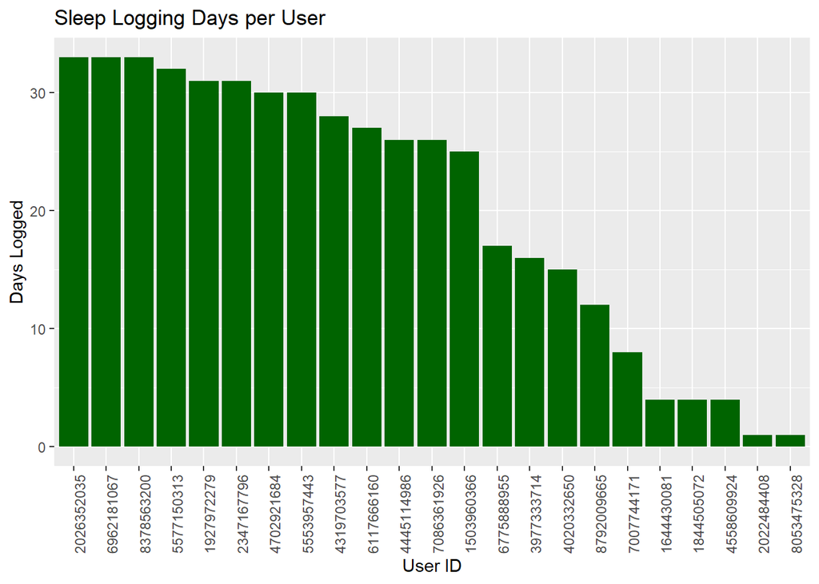

```r
# 📊 Sleep logging days
sleep_engagement <- sleep_per_minute_clean %>%
  mutate(sleep_date = as_date(mdy_hms(date))) %>%
  group_by(id) %>%
  summarise(sleep_days_logged = n_distinct(sleep_date), .groups = "drop")

# 📊 Sleep logging plot
print(
  ggplot(sleep_engagement, aes(x = reorder(id, -sleep_days_logged), y = sleep_days_logged)) +
    geom_bar(stat = "identity", fill = "darkgreen") +
    labs(title = "Sleep Logging Days per User", x = "User ID", y = "Days Logged") +
    theme(axis.text.x = element_text(angle = 90, hjust = 1))
)
```

### Interpretation:

While sleep tracking shows better adoption than other metrics (like weight logging), there’s significant room to improve consistency among moderately and minimally engaged users. The data suggests sleep tracking is established but not yet a habitual behavior for most users.

So what?: Even though it’s not a habitual behavior, this graph reveals sleep tracking is Bellabeat’s strongest engagement driver among measured metrics - worth examining what makes it work better than weight/activity tracking.

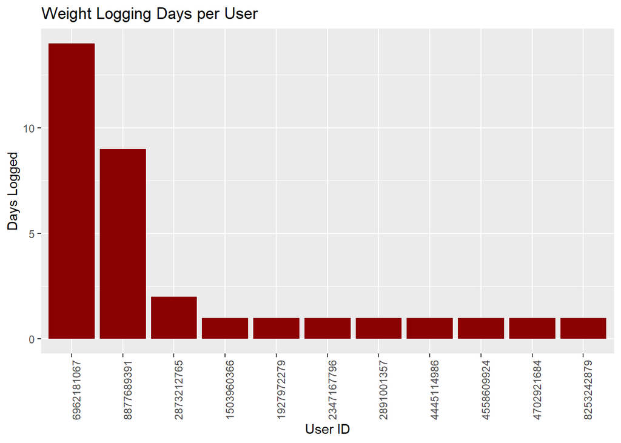

```r
# 📊 Weight logging days
weight_engagement <- weight_tracking_clean %>%
  mutate(weight_date = as_date(mdy_hms(date))) %>%
  group_by(id) %>%
  summarise(weight_days_logged = n_distinct(weight_date), .groups = "drop")

# 📊 Weight logging plot
print(
  ggplot(weight_engagement, aes(x = reorder(id, -weight_days_logged), y = weight_days_logged)) +
    geom_bar(stat = "identity", fill = "darkred") +
    labs(title = "Weight Logging Days per User", x = "User ID", y = "Days Logged") +
    theme(axis.text.x = element_text(angle = 90, hjust = 1))
)
```

#### NOTE: Weight trends are previously discussed!

### Interpretation

**Activity Logging:** Most users log activity infrequently, while a small group is consistent. Bellabeat should focus on less engaged users with nudges, habit tools, or easier tracking options.

**Sleep Logging:** Sleep tracking is more consistent than weight tracking for many users but still varies. Reminders and visual progress feedback can support steady logging habits.

**Weight Logging:** Weight tracking is least consistent, with most users logging only once. Bellabeat could explore ways to encourage more consistent weight tracking, such as reminders, goal-setting tools, or progress visualizations to boost motivation.

#–

# 📊 Analysis Phase 5: User Segmentation Analysis

### Purpose

This phase segments users based on their logging patterns for activity, sleep, and weight. The goal is to identify distinct user groups by engagement level, so Bellabeat can design personalized retention and activation strategies to move more users toward healthy, consistent habits.

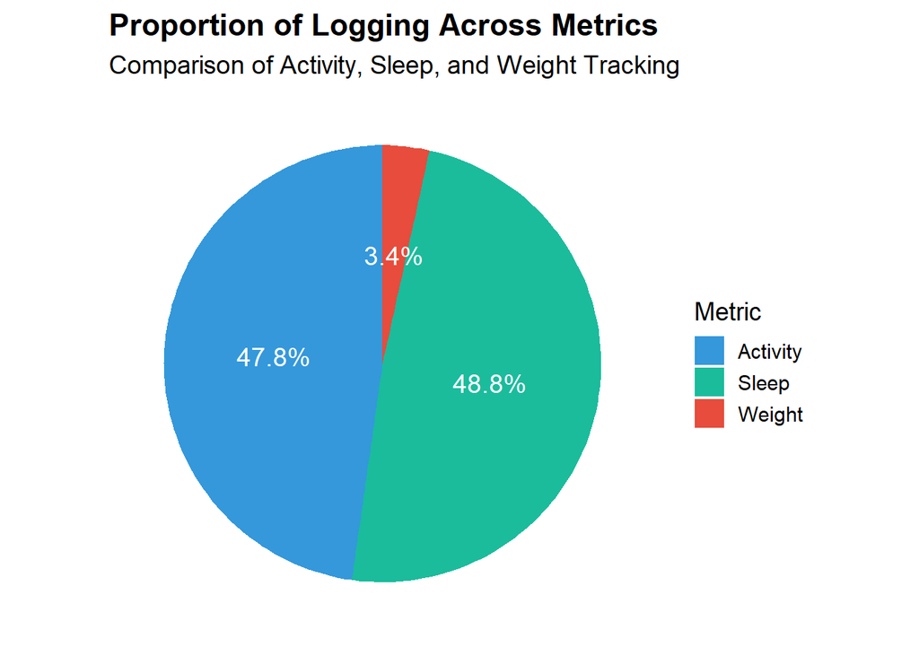

```r
# 📦 Load required packages
library(dplyr)
library(lubridate)
library(ggplot2)
library(tidyr)

# 🧮 Step 1: Create summary metrics per user
activity_engagement <- daily_activity_clean %>%
  group_by(id) %>%
  summarise(ActivityLogged = n_distinct(activity_date), .groups = "drop")

sleep_engagement <- sleep_per_minute_clean %>%
  mutate(SleepDate = as_date(mdy_hms(date))) %>%
  group_by(id) %>%
  summarise(SleepLogged = n_distinct(SleepDate), .groups = "drop")

weight_engagement <- weight_tracking_clean %>%
  mutate(WeightDate = as_date(mdy_hms(date))) %>%
  group_by(id) %>%
  summarise(WeightLogged = n_distinct(WeightDate), .groups = "drop")

# Combine and reshape for stacked percentage plot
engagement_long <- activity_engagement %>%
  full_join(sleep_engagement, by = "id") %>%
  full_join(weight_engagement, by = "id") %>%
  replace_na(list(ActivityLogged = 0, SleepLogged = 0, WeightLogged = 0)) %>%
  pivot_longer(cols = c(ActivityLogged, SleepLogged, WeightLogged),
               names_to = "Metric", values_to = "DaysLogged") %>%
  mutate(Metric = recode(Metric,
                         "ActivityLogged" = "Activity",
                         "SleepLogged" = "Sleep",
                         "WeightLogged" = "Weight"))

# Calculate percentage per user
engagement_pct <- engagement_long %>%
  group_by(Metric) %>%
  summarise(TotalLogged = sum(DaysLogged)) %>%
  mutate(Percentage = TotalLogged / sum(TotalLogged) * 100)

# 📊 Pie chart of logging proportions with percentage labels
print(
  ggplot(engagement_pct, aes(x = "", y = Percentage, fill = Metric)) +
    geom_bar(stat = "identity", width = 1) +
    coord_polar(theta = "y") +
    geom_text(aes(label = paste0(round(Percentage, 1), "%")),
              position = position_stack(vjust = 0.5),
              color = "white",
              size = 5) +
    scale_fill_manual(values = c("Activity" = "#3498DB", "Sleep" = "#1ABC9C", "Weight" = "#E74C3C")) +
    labs(
      title = "Proportion of Logging Across Metrics",
      subtitle = "Comparison of Activity, Sleep, and Weight Tracking",
      fill = "Metric"
    ) +
    theme_minimal(base_size = 14) +
    theme(
      axis.title.x = element_blank(),
      axis.title.y = element_blank(),
      axis.text = element_blank(),
      axis.ticks = element_blank(),
      panel.grid = element_blank(),
      plot.title = element_text(face = "bold")
    )
)
```

### Interpretation:

Sleep tracking (48.8%) and activity tracking (47.8%) are nearly equal in engagement, while weight tracking is very low (3.4%). This suggests users are equally consistent in tracking sleep and activity, but rarely log their weight.

#### So what?:

Bellabeat’s users maintain strong habits for both sleep and activity tracking, but weight tracking is underused. Encouraging or automating weight logging could help complete the health-tracking picture and improve product stickiness.

## **Insights & Recommendations for Bellabeat Case Study**

### **Strategic Recommendations**

#### **Conclusion**

Bellabeat’s data reveals **sleep as a strength** and **weight tracking as a critical gap**. By automating manual inputs, gamifying consistency, and tailoring strategies to user segments, Bellabeat can transform sporadic users into habitual trackers—driving long-term engagement and healthier behaviors.

**Next Steps:**  
Pilot automated weight sync with Bellabeat devices.  
A/B test incentive programs for activity/sleep consistency.  
Develop segmented marketing campaigns based on engagement tiers.